# Informe Final del Ensayo de Aptitud (EA)

Medición de Gases Contaminantes Criterio CO, SO₂

Laboratorio CALAIRE

2026-05-29

# 1. Introduccion

Este informe presenta los resultados del Ensayo de Aptitud (EA) para la medicion de gases contaminantes criterio en aire cero, conforme a la norma ISO/IEC 17043:2023 y los metodos estadisticos de la norma ISO 13528:2022. El documento resume la informacion del esquema, la participacion, la metodologia y los resultados obtenidos.

## 1.1. Información del Proveedor y del esquema

**Alcance:** Este Ensayo de Aptitud (EA) por comparación interlaboratorio abarca la medición de los gases contaminantes criterio CO y SO₂ en aire cero, según lo definido en el EA-PP2026-R1.

**Objetivo Principal:** Evaluar el desempeño de los laboratorios participantes en la medición de los gases contaminantes criterio, conforme a los requisitos de la norma ISO/IEC 17043:2023 y utilizando los métodos estadísticos de la norma ISO 13528:2022.

## 1.2. Confidencialidad y Uso del Informe

La identidad de los participantes es confidencial y solo conocida por el personal autorizado de CALAIRE involucrado en la operación del esquema de EA. Se utilizan códigos de laboratorio anonimizados en este informe para asegurar la confidencialidad, según lo estipulado en la política de confidencialidad del laboratorio. Este informe es para uso de los participantes y, cuando aplique, de sus organismos de acreditación o autoridades regulatorias. Cualquier otro uso debe ser autorizado por CALAIRE.

## 1.3. Roles de Autorización y Personal Clave

La organización, ejecución y evaluación de este EA se realizó bajo la responsabilidad del Laboratorio CALAIRE. Los roles clave involucrados fueron:

**Coordinador EA:** Carmen Elena Zapata  
**Profesional Calidad Aire:** Wilson Salas  
**Profesional Proyectos:** David Pulgarín  
**Profesional Infraestructura:** Maira Herra  
**Ingeniero Operativo:** Fabian Moreno  
**Profesional de Gestión de Calidad:** Jeniffer Ochoa

## 1.4. Participantes e Instrumentación

En esta ronda del EA participaron 1 laboratorios. A continuación, se lista a los participantes (mediante código asignado).

Tabla 2. Participantes del Ensayo de Aptitud

| Código Lab | Analizador SO₂ (Marca/Modelo) | Analizador CO (Marca/Modelo) |
| --- | --- | --- |
| REFERENCIA | HORIBA APSA- 370 | Teledyne T300 |
| p1 | Teledyne T100 | Teledyne T300 |

# 2. Descripción del Ensayo y Metodología

## 2.1. Ítems de Ensayo y Producción

**Descripción:** Los ítems de ensayo consistieron en atmósferas de gas CO y SO₂ en aire cero, generadas dinámicamente y suministradas a los participantes a través de un colector de distribución (manifold) de vidrio inerte.

**Método de Producción:**

- **CO, SO₂:** Generados por dilución dinámica de Materiales Certificados de Referencia (MCR) trazables, utilizando controladores de flujo másico calibrados.

Tabla 3. Niveles de concentración del ítem de ensayo (Valores de Referencia)

| Corrida | co | so2 |
| --- | --- | --- |
| 1 | -0.02 | -0.03 |
| 2 | 6.29 | 179.11 |
| 3 | 4.16 | 120.67 |
| 4 | 2.77 | 80.53 |
| 5 | 1.39 | 40.50 |

*Los valores de concentración obedecen a los intervalos de medición establecidos en la normativa vigente y lo estipulado en los métodos US-EPA.

**Instrucciones a Participantes:** Se solicitó a los participantes reportar [3] mediciones promedio de [1 h] para cada nivel de concentración a partir de los niveles de concentración minutales.

## 2.2. Homogeneidad y Estabilidad de los Ítems de EA

Dado que los ítems de ensayo se generan dinámicamente y se miden in situ, la evaluación de homogeneidad y estabilidad se enfoca en el sistema de generación y distribución.

**Homogeneidad:** Se verificó la homogeneidad del gas distribuido a través del manifold antes del inicio del EA, midiendo la concentración en diferentes puntos de salida según ISO 13528:2022, Anexo B. Los datos de homogeneidad se presentan en el Anexo B.

**Estabilidad:** Se monitoreó la estabilidad de la concentración generada durante cada corrida mediante los instrumentos de referencia de CALAIRE, según ISO 13528:2022, Anexo B. Los datos de estabilidad se presentan en el Anexo B.

## 2.3. Determinación del Valor Asignado ($x_{pt}$) y su desviación ($\sigma_{pt}$)

El valor asignado se determinó por valor de referencia para cada contaminante y nivel.

La desviación estándar para la evaluación de la aptitud ($\sigma_{pt}$) se estableció para cada contaminante por criterio de expertos.

## 2.4. Compatibilidad Metrológica

Se evaluó la compatibilidad metrológica para el criterio de expertos, usando el valor de referencia como $x_{pt}$ y la desviación para evaluación de aptitud calculada por criterio de expertos.

Tabla. Compatibilidad Metrológica: Diferencias entre Valor de Referencia y Consenso

| Contaminante | N_Lab | Nivel | Valor Ref | Valor Expertos 4 | sigma_pt Expertos | Dif (Ref - 4) |
| --- | --- | --- | --- | --- | --- | --- |
| co | 1 | 0-µmol/mol | -0.024 | -0.024 | 0.0994 | 0 |
| co | 1 | 1.4-µmol/mol | 1.390 | 1.390 | 0.1334 | 0 |
| co | 1 | 2.8-µmol/mol | 2.771 | 2.771 | 0.1665 | 0 |
| co | 1 | 4.2-µmol/mol | 4.165 | 4.165 | 0.2000 | 0 |
| co | 1 | 6.3-µmol/mol | 6.293 | 6.293 | 0.2510 | 0 |
| so2 | 1 | 0-nmol/mol | -0.031 | -0.031 | 0.9993 | 0 |
| so2 | 1 | 119-nmol/mol | 120.666 | 120.666 | 3.6547 | 0 |
| so2 | 1 | 179-nmol/mol | 179.108 | 179.108 | 4.9404 | 0 |
| so2 | 1 | 40-nmol/mol | 40.498 | 40.498 | 1.8910 | 0 |
| so2 | 1 | 80-nmol/mol | 80.533 | 80.533 | 2.7717 | 0 |

# 3. Criterios de Evaluación

## 3.1. Indicadores de Desempeño y criterios de evaluación

Se calcularon los siguientes indicadores de desempeño para cada resultado reportado $x_i$ por cada participante:

Tabla. Criterios de evaluación del desempeño

| Indicador | Ecuación | Evaluación |
| --- | --- | --- |
| Puntuación z | $z = \frac{x_i - x_{pt}}{\sigma_{pt}}$ | \|z\| ≤ 2.0: **Satisfactorio** 2.0 < \|z\| < 3.0: **Cuestionable** \|z\| ≥ 3.0: **Insatisfactorio** |

## 3.2. Tratamiento Estadístico de Datos

**Recepción y Validación:** Los resultados reportados por los participantes fueron recibidos a través del Aplicativo Web/Formulario y validados para verificar formato, unidades y completitud.

**Identificación de atípicos:** Se realizó una revisión de los datos para identificar posibles errores y atípicos, según ISO 13528:2022, 6.3. Para ello se llevó a cabo la prueba de Grubbs para atípicos, encontrando los siguientes resultados:

Tabla 4. Resultados de la prueba de Grubbs para atípicos

| Contaminante | Nivel | Participantes Evaluados | Valor p | Atípicos detectados | Participante | Valor Atípico |
| --- | --- | --- | --- | --- | --- | --- |
| co | 0-µmol/mol | 1 | NA | 0 | NA | NA |
| co | 1.4-µmol/mol | 1 | NA | 0 | NA | NA |
| co | 2.8-µmol/mol | 1 | NA | 0 | NA | NA |
| co | 4.2-µmol/mol | 1 | NA | 0 | NA | NA |
| co | 6.3-µmol/mol | 1 | NA | 0 | NA | NA |
| so2 | 0-nmol/mol | 1 | NA | 0 | NA | NA |
| so2 | 119-nmol/mol | 1 | NA | 0 | NA | NA |
| so2 | 179-nmol/mol | 1 | NA | 0 | NA | NA |
| so2 | 40-nmol/mol | 1 | NA | 0 | NA | NA |
| so2 | 80-nmol/mol | 1 | NA | 0 | NA | NA |

# 4. Resultados y Discusión

## 4.1. Resumen General del Desempeño

En esta ronda del EA, participaron 1 laboratorios.

Tabla 5. Resumen de desempeño por indicador

|  | Indicador | Evaluación | co | so2 | TOTAL | TOTAL (%) |
| --- | --- | --- | --- | --- | --- | --- |
| z_sat | z-score | Satisfactorio | 5 | 5 | 10 | 100.00% |
| z_quest | z-score | No aplica | 0 | 0 | 0 | 0.00% |
| z_unsat | z-score | No aplica | 0 | 0 | 0 | 0.00% |

## 4.2. Evaluación por Contaminante

A continuación, se presenta un resumen del desempeño para cada contaminante.

### Resultados para CO

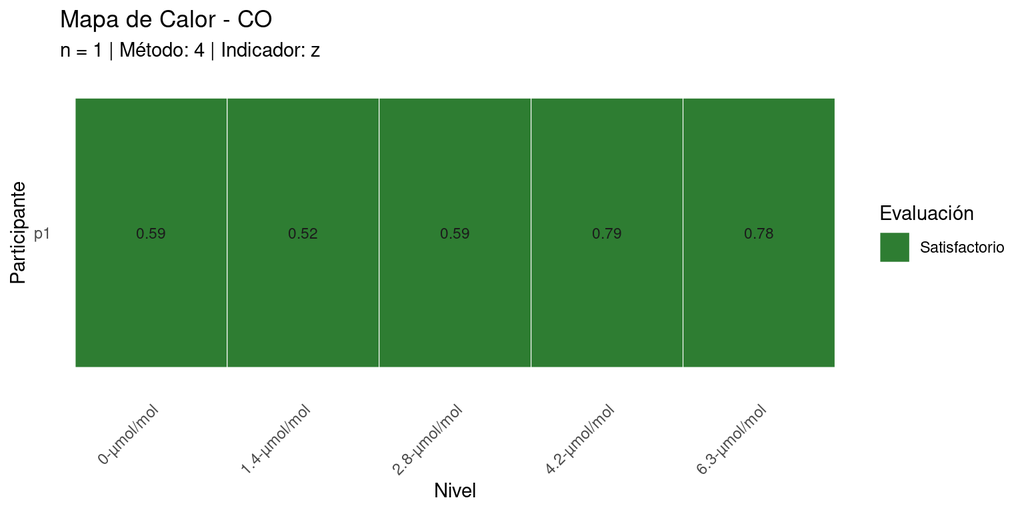

Figura. Mapa de Calor para las puntuaciones para CO por participante.

### Resultados para SO2

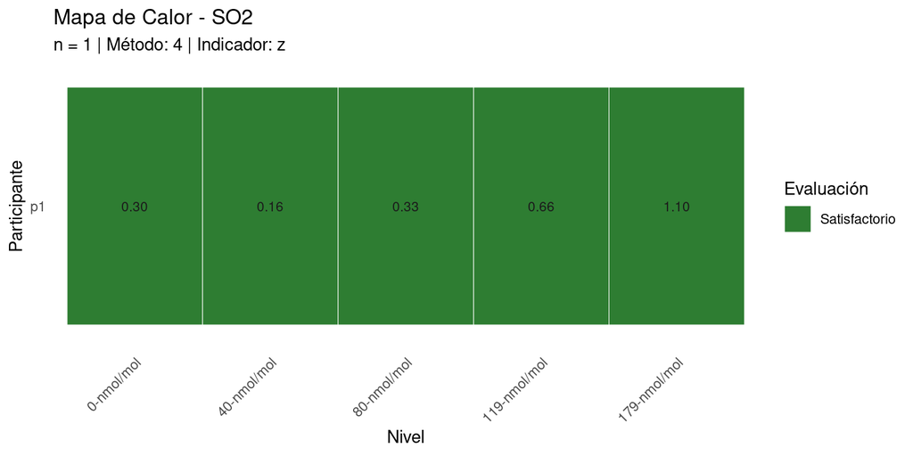

Figura. Mapa de Calor para las puntuaciones para SO2 por participante.

# 5. Conclusiones

**Conformidad General:** El desempeño general de los laboratorios participantes en esta ronda fue satisfactorio.

**Áreas de Preocupación:** No se identificaron resultados cuestionables o insatisfactorios en esta ronda.

**Acciones Sugeridas para Participantes:** Mantener los controles metrológicos y el seguimiento rutinario de los procedimientos para conservar el desempeño observado.

# Anexo A: Valores Asignados y Desviación Estándar para Evaluación de Aptitud

A continuación se presenta el resumen de los valores asignados ($x_{pt}$), incertidumbres ($u(x_{pt})$) y desviaciones estándar para la evaluación de la aptitud ($\sigma_{pt}$) para cada contaminante y nivel. La tabla incluye el método seleccionado y, cuando corresponde, el método de expertos con $x_{pt}$ tomado de la referencia.

Tabla A.1. Resumen de Valores Asignados y Parámetros Estadísticos

| Contaminante | Nivel | Método | Valor Asignado (x_pt) | Incertidumbre u(x_pt) | u_ref | Desviación (sigma_pt) |
| --- | --- | --- | --- | --- | --- | --- |
| co | 0-µmol/mol | Expertos | -0.024 | -0.0001 | NA | 0.0994 |
| co | 1.4-µmol/mol | Expertos | 1.390 | 0.0042 | NA | 0.1334 |
| co | 2.8-µmol/mol | Expertos | 2.771 | 0.0083 | NA | 0.1665 |
| co | 4.2-µmol/mol | Expertos | 4.165 | 0.0125 | NA | 0.2000 |
| co | 6.3-µmol/mol | Expertos | 6.293 | 0.0189 | NA | 0.2510 |
| so2 | 0-nmol/mol | Expertos | -0.031 | -0.0001 | NA | 0.9993 |
| so2 | 119-nmol/mol | Expertos | 120.666 | 0.3620 | NA | 3.6547 |
| so2 | 179-nmol/mol | Expertos | 179.108 | 0.5373 | NA | 4.9404 |
| so2 | 40-nmol/mol | Expertos | 40.498 | 0.1215 | NA | 1.8910 |
| so2 | 80-nmol/mol | Expertos | 80.533 | 0.2416 | NA | 2.7717 |

# Anexo B: Resumen de Homogeneidad y Estabilidad

## B.1. Resumen de Homogeneidad

Tabla B.1. Resumen de Evaluación de Homogeneidad

| Contaminante | Nivel | Items | Réplicas | sigma_pt | u(x_pt) | ss | sw | Criterio c | Cumple | Conclusión |
| --- | --- | --- | --- | --- | --- | --- | --- | --- | --- | --- |
| co | 0-µmol/mol | 10 | 2 | 0.0779 | 0.0308 | 0.0000 | 0.0391 | 0.0234 | Sí | ss (0.0000) ≤ c_MADe (0.0234): CUMPLE CRITERIO HOMOGENEIDAD (MADe) ss (0.0000) ≤ c_MADe_exp (0.0026): CUMPLE CRITERIO EXP HOMOGENEIDAD (MADe) |
| co | 1.4-µmol/mol | 10 | 2 | 0.0037 | 0.0015 | 0.0010 | 0.0047 | 0.0011 | Sí | ss (0.0010) ≤ c_MADe (0.0011): CUMPLE CRITERIO HOMOGENEIDAD (MADe) ss (0.0010) > c_MADe_exp (0.0000): NO CUMPLE CRITERIO EXP HOMOGENEIDAD (MADe) |
| co | 2.8-µmol/mol | 10 | 2 | 0.0052 | 0.0021 | 0.0012 | 0.0052 | 0.0016 | Sí | ss (0.0012) ≤ c_MADe (0.0016): CUMPLE CRITERIO HOMOGENEIDAD (MADe) ss (0.0012) > c_MADe_exp (0.0000): NO CUMPLE CRITERIO EXP HOMOGENEIDAD (MADe) |
| co | 4.2-µmol/mol | 10 | 2 | 0.0171 | 0.0067 | 0.0000 | 0.0149 | 0.0051 | Sí | ss (0.0000) ≤ c_MADe (0.0051): CUMPLE CRITERIO HOMOGENEIDAD (MADe) ss (0.0000) ≤ c_MADe_exp (0.0003): CUMPLE CRITERIO EXP HOMOGENEIDAD (MADe) |
| co | 6.3-µmol/mol | 10 | 2 | 0.0044 | 0.0018 | 0.0000 | 0.0057 | 0.0013 | Sí | ss (0.0000) ≤ c_MADe (0.0013): CUMPLE CRITERIO HOMOGENEIDAD (MADe) ss (0.0000) ≤ c_MADe_exp (0.0000): CUMPLE CRITERIO EXP HOMOGENEIDAD (MADe) |
| so2 | 0-nmol/mol | 10 | 2 | 0.2595 | 0.1026 | 0.0562 | 0.2991 | 0.0779 | Sí | ss (0.0562) ≤ c_MADe (0.0779): CUMPLE CRITERIO HOMOGENEIDAD (MADe) ss (0.0562) ≤ c_MADe_exp (0.1017): CUMPLE CRITERIO EXP HOMOGENEIDAD (MADe) |
| so2 | 119-nmol/mol | 10 | 2 | 0.2076 | 0.0821 | 0.1769 | 0.1673 | 0.0623 | No | ss (0.1769) > c_MADe (0.0623): NO CUMPLE CRITERIO HOMOGENEIDAD (MADe) ss (0.1769) > c_MADe_exp (0.0356): NO CUMPLE CRITERIO EXP HOMOGENEIDAD (MADe) |
| so2 | 179-nmol/mol | 10 | 2 | 1.0863 | 0.4294 | 0.2155 | 0.5940 | 0.3259 | Sí | ss (0.2155) ≤ c_MADe (0.3259): CUMPLE CRITERIO HOMOGENEIDAD (MADe) ss (0.2155) ≤ c_MADe_exp (0.5560): CUMPLE CRITERIO EXP HOMOGENEIDAD (MADe) |
| so2 | 40-nmol/mol | 10 | 2 | 0.0311 | 0.0123 | 0.0000 | 0.0721 | 0.0093 | Sí | ss (0.0000) ≤ c_MADe (0.0093): CUMPLE CRITERIO HOMOGENEIDAD (MADe) ss (0.0000) ≤ c_MADe_exp (0.0054): CUMPLE CRITERIO EXP HOMOGENEIDAD (MADe) |
| so2 | 80-nmol/mol | 10 | 2 | 0.1327 | 0.0525 | 0.0000 | 0.1361 | 0.0398 | Sí | ss (0.0000) ≤ c_MADe (0.0398): CUMPLE CRITERIO HOMOGENEIDAD (MADe) ss (0.0000) ≤ c_MADe_exp (0.0217): CUMPLE CRITERIO EXP HOMOGENEIDAD (MADe) |

## B.2. Resumen de Estabilidad

Tabla B.2. Resumen de Evaluación de Estabilidad

| Contaminante | Nivel | Items | Réplicas | sigma_pt | u(x_pt) | Diferencia | Criterio c | Cumple | Conclusión |
| --- | --- | --- | --- | --- | --- | --- | --- | --- | --- |
| co | 0-µmol/mol | 2 | 2 | 0.0779 | 0.0007 | 0.0162 | 0.0234 | Sí | ss (0.0162) ≤ c_MADe (0.0234): CUMPLE CRITERIO ESTABILIDAD (MADe) ss (0.0162) ≤ c_MADe_exp (0.4697): CUMPLE CRITERIO EXP ESTABILIDAD (MADe) |
| co | 1.4-µmol/mol | 2 | 2 | 0.0037 | 0.0072 | 0.0012 | 0.0011 | No | ss (0.0012) > c_MADe (0.0011): NO CUMPLE CRITERIO ESTABILIDAD (MADe) ss (0.0012) ≤ c_MADe_exp (0.4463): CUMPLE CRITERIO EXP ESTABILIDAD (MADe) |
| co | 2.8-µmol/mol | 2 | 2 | 0.0052 | 0.0072 | 0.0034 | 0.0016 | No | ss (0.0034) > c_MADe (0.0016): NO CUMPLE CRITERIO ESTABILIDAD (MADe) ss (0.0034) ≤ c_MADe_exp (0.4467): CUMPLE CRITERIO EXP ESTABILIDAD (MADe) |
| co | 4.2-µmol/mol | 2 | 2 | 0.0171 | 0.0072 | 0.0058 | 0.0051 | No | ss (0.0058) > c_MADe (0.0051): NO CUMPLE CRITERIO ESTABILIDAD (MADe) ss (0.0058) ≤ c_MADe_exp (0.4503): CUMPLE CRITERIO EXP ESTABILIDAD (MADe) |
| co | 6.3-µmol/mol | 2 | 2 | 0.0044 | 0.0007 | 0.0019 | 0.0013 | No | ss (0.0019) > c_MADe (0.0013): NO CUMPLE CRITERIO ESTABILIDAD (MADe) ss (0.0019) ≤ c_MADe_exp (0.4465): CUMPLE CRITERIO EXP ESTABILIDAD (MADe) |
| so2 | 0-nmol/mol | 2 | 2 | 0.2595 | 0.2379 | 0.0543 | 0.0779 | Sí | ss (0.0543) ≤ c_MADe (0.0779): CUMPLE CRITERIO ESTABILIDAD (MADe) ss (0.0543) ≤ c_MADe_exp (10.3724): CUMPLE CRITERIO EXP ESTABILIDAD (MADe) |
| so2 | 119-nmol/mol | 2 | 2 | 0.2076 | 0.3061 | 0.1895 | 0.0623 | No | ss (0.1895) > c_MADe (0.0623): NO CUMPLE CRITERIO ESTABILIDAD (MADe) ss (0.1895) ≤ c_MADe_exp (10.3593): CUMPLE CRITERIO EXP ESTABILIDAD (MADe) |
| so2 | 179-nmol/mol | 2 | 2 | 1.0863 | 0.5768 | 0.0606 | 0.3259 | Sí | ss (0.0606) ≤ c_MADe (0.3259): CUMPLE CRITERIO ESTABILIDAD (MADe) ss (0.0606) ≤ c_MADe_exp (10.6338): CUMPLE CRITERIO EXP ESTABILIDAD (MADe) |
| so2 | 40-nmol/mol | 2 | 2 | 0.0311 | 0.0511 | 0.0442 | 0.0093 | No | ss (0.0442) > c_MADe (0.0093): NO CUMPLE CRITERIO ESTABILIDAD (MADe) ss (0.0442) ≤ c_MADe_exp (10.3024): CUMPLE CRITERIO EXP ESTABILIDAD (MADe) |
| so2 | 80-nmol/mol | 2 | 2 | 0.1327 | 0.0013 | 0.0048 | 0.0398 | Sí | ss (0.0048) ≤ c_MADe (0.0398): CUMPLE CRITERIO ESTABILIDAD (MADe) ss (0.0048) ≤ c_MADe_exp (10.3334): CUMPLE CRITERIO EXP ESTABILIDAD (MADe) |

# Anexo C: Resultados por Participante

A continuación se presentan los resultados detallados para cada participante.

## Código: p1

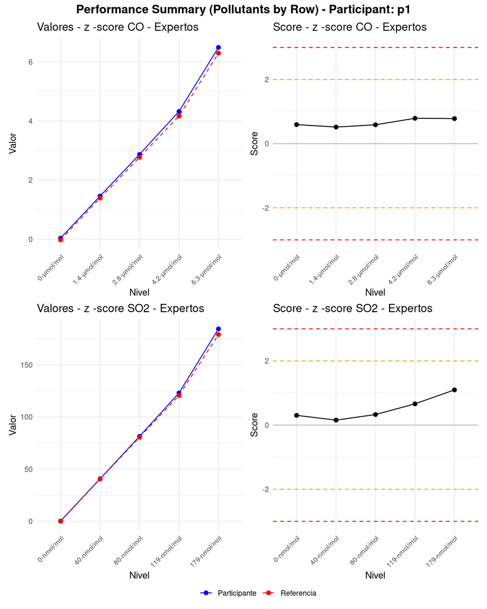

Figura. Matriz de desempeño para el participante p1

### Tabla de Resultados

Resultados detallados - Participante p1

| Contaminante | Nivel | Método | Resultado | Incertidumbre | Valor Asignado | Incertidumbre VA | sigma_pt | Score | Evaluación |
| --- | --- | --- | --- | --- | --- | --- | --- | --- | --- |
| co | 0-µmol/mol | Expertos | 0.035 | 0.003 | -0.024 | -0.0001 | 0.0994 | 0.5934 | Satisfactorio |
| co | 1.4-µmol/mol | Expertos | 1.459 | 0.006 | 1.390 | 0.0042 | 0.1334 | 0.5174 | Satisfactorio |
| co | 2.8-µmol/mol | Expertos | 2.869 | 0.005 | 2.771 | 0.0083 | 0.1665 | 0.5886 | Satisfactorio |
| co | 4.2-µmol/mol | Expertos | 4.323 | 0.011 | 4.165 | 0.0125 | 0.2000 | 0.7902 | Satisfactorio |
| co | 6.3-µmol/mol | Expertos | 6.489 | 0.008 | 6.293 | 0.0189 | 0.2510 | 0.7808 | Satisfactorio |
| so2 | 0-nmol/mol | Expertos | 0.272 | 0.028 | -0.031 | -0.0001 | 0.9993 | 0.3032 | Satisfactorio |
| so2 | 119-nmol/mol | Expertos | 123.091 | 0.218 | 120.666 | 0.3620 | 3.6547 | 0.6635 | Satisfactorio |
| so2 | 179-nmol/mol | Expertos | 184.535 | 0.559 | 179.108 | 0.5373 | 4.9404 | 1.0985 | Satisfactorio |
| so2 | 40-nmol/mol | Expertos | 40.792 | 0.056 | 40.498 | 0.1215 | 1.8910 | 0.1555 | Satisfactorio |
| so2 | 80-nmol/mol | Expertos | 81.446 | 0.245 | 80.533 | 0.2416 | 2.7717 | 0.3294 | Satisfactorio |